# Assignment 6

```python
import pandas as pd
import numpy as np
import matplotlib.pyplot as plt
import seaborn as sns
from sklearn.linear_model import LogisticRegression
from sklearn import metrics
from sklearn.metrics import classification_report, accuracy_score, confusion_matrix
from sklearn import preprocessing
from sklearn.preprocessing import StandardScaler
from sklearn.preprocessing import LabelEncoder
from sklearn.model_selection import train_test_split
from sklearn.metrics import confusion_matrix
from sklearn.metrics import roc_auc_score
from sklearn.metrics import roc_curve
import statsmodels.api as sm
from sklearn.feature_selection import SelectKBest
from sklearn.feature_selection import chi2
from sklearn.model_selection import KFold
from sklearn.model_selection import GridSearchCV
from sklearn.ensemble import IsolationForest
from sklearn.neighbors import LocalOutlierFactor
from sklearn.svm import OneClassSVM
from pylab import rcParams
rcParams['figure.figsize'] = 14, 8
RANDOM_SEED = 42
LABELS = ["Subscribe", "Not_Subscribe"]
from imblearn.under_sampling import NearMiss
from collections import Counter
from imblearn.combine import SMOTETomek
```

```python
data = pd.read_csv(r"E:\ExcelR Assignment\Assignment 6 - Logistic Regression\bank-full.csv",sep=';')
data.head()
```

|  | age | job | marital | education | default | balance | housing | loan | contact | day | month | duration | campaign | pdays | previous | poutcome | y |
| --- | --- | --- | --- | --- | --- | --- | --- | --- | --- | --- | --- | --- | --- | --- | --- | --- | --- |
| 0 | 58 | management | married | tertiary | no | 2143 | yes | no | unknown | 5 | may | 261 | 1 | -1 | 0 | unknown | no |
| 1 | 44 | technician | single | secondary | no | 29 | yes | no | unknown | 5 | may | 151 | 1 | -1 | 0 | unknown | no |
| 2 | 33 | entrepreneur | married | secondary | no | 2 | yes | yes | unknown | 5 | may | 76 | 1 | -1 | 0 | unknown | no |
| 3 | 47 | blue-collar | married | unknown | no | 1506 | yes | no | unknown | 5 | may | 92 | 1 | -1 | 0 | unknown | no |
| 4 | 33 | unknown | single | unknown | no | 1 | no | no | unknown | 5 | may | 198 | 1 | -1 | 0 | unknown | no |

### DATA ANALYSIS

```python
# Univaraite Analysis

data.describe()
```

|  | age | balance | day | duration | campaign | pdays | previous |
| --- | --- | --- | --- | --- | --- | --- | --- |
| count | 45211.000000 | 45211.000000 | 45211.000000 | 45211.000000 | 45211.000000 | 45211.000000 | 45211.000000 |
| mean | 40.936210 | 1362.272058 | 15.806419 | 258.163080 | 2.763841 | 40.197828 | 0.580323 |
| std | 10.618762 | 3044.765829 | 8.322476 | 257.527812 | 3.098021 | 100.128746 | 2.303441 |
| min | 18.000000 | -8019.000000 | 1.000000 | 0.000000 | 1.000000 | -1.000000 | 0.000000 |
| 25% | 33.000000 | 72.000000 | 8.000000 | 103.000000 | 1.000000 | -1.000000 | 0.000000 |
| 50% | 39.000000 | 448.000000 | 16.000000 | 180.000000 | 2.000000 | -1.000000 | 0.000000 |
| 75% | 48.000000 | 1428.000000 | 21.000000 | 319.000000 | 3.000000 | -1.000000 | 0.000000 |
| max | 95.000000 | 102127.000000 | 31.000000 | 4918.000000 | 63.000000 | 871.000000 | 275.000000 |

```python
data.isnull().sum()
```

```
age          0
job          0
marital      0
education    0
default      0
balance      0
housing      0
loan         0
contact      0
day          0
month        0
duration     0
campaign     0
pdays        0
previous     0
poutcome     0
y            0
dtype: int64
```

### No NULL Values

```python
data.groupby('y').mean()
```

| y | age | balance | day | duration | campaign | pdays | previous |
| --- | --- | --- | --- | --- | --- | --- | --- |
| no | 40.838986 | 1303.714969 | 15.892290 | 221.182806 | 2.846350 | 36.421372 | 0.502154 |
| yes | 41.670070 | 1804.267915 | 15.158253 | 537.294574 | 2.141047 | 68.702968 | 1.170354 |

```python
data['y'].value_counts()
```

```
no     39922
yes     5289
Name: y, dtype: int64
```

```python
No = len(data[data.y=='no'])
Yes = len(data[data.y=='yes'])
Yes_Percent = (Yes/len(data['y']))*100
No_Percent = (No/len(data['y']))*100
print('Percent of Yes: ' + str(Yes_Percent))
print('Percent of No:  ' + str(No_Percent))
```

```
Percent of Yes: 11.698480458295547
Percent of No:  88.30151954170445
```

[figure not shown]

```python
count_classes = pd.value_counts(data['y'], sort = True)

count_classes.plot(kind = 'bar', rot=0)

plt.title("Term Deposit Subscription")

plt.xticks(range(2), LABELS)

plt.xlabel("y")

plt.ylabel("Frequency")
```

#### So, this data has many NO compared to YES.

#### Therefore, data is biased to NO and most of the time answer would be no despite it could have been yes.

```python
Subscribe = data[data['y']=='yes']

Not_Subscribe = data[data['y']=='no']
```

```python
print(Subscribe.shape,Not_Subscribe.shape)
```

```
(5289, 17) (39922, 17)
```

## Checking behaviour of variables with target variable

#### Age vs Target Variable

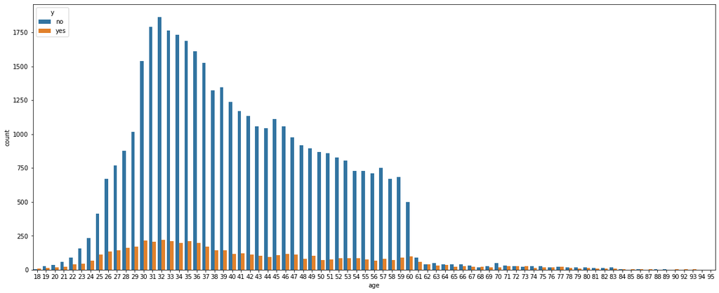

```python
plt.figure(figsize=(20,8))
sns.countplot(x="age",data=data,hue="y")
```

#### Job - Default

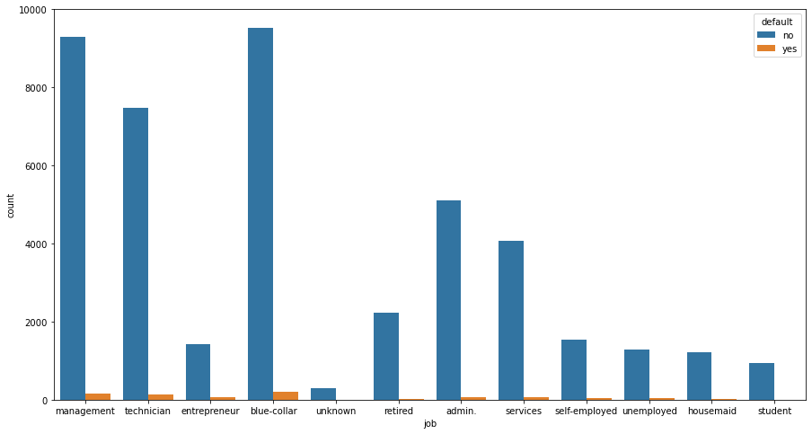

```python
plt.figure(figsize=(15,8))
sns.countplot(x="job",data=data,hue="default")
```

#### Job - Personal Loan

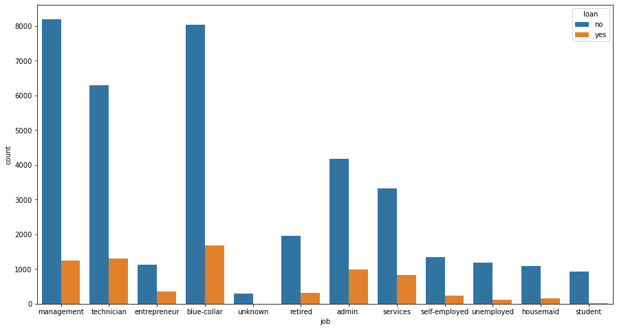

```python
plt.figure(figsize=(15,8))
sns.countplot(x="job",data=data,hue="loan")
```

#### Job - Housing Loan

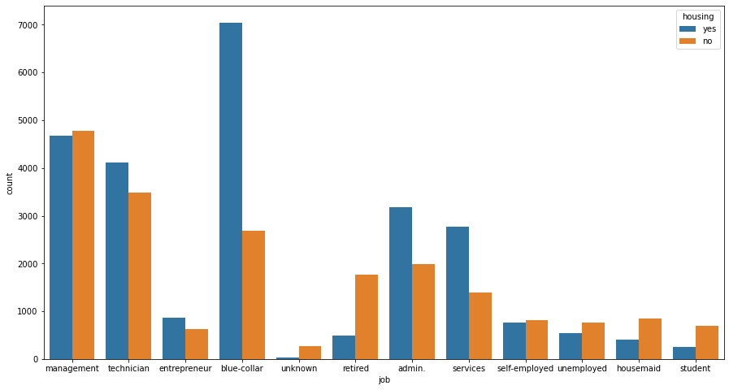

```python
plt.figure(figsize=(15,8))
sns.countplot(x="job",data=data,hue="housing")
```

#### Job - Target Variable

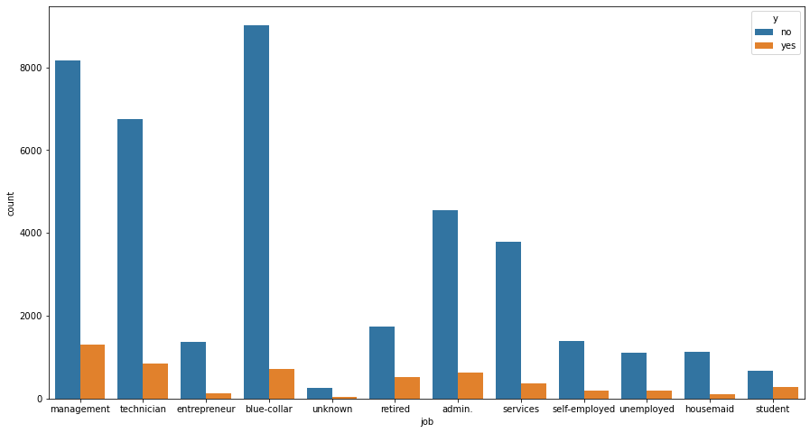

```python
plt.figure(figsize=(15,8))
sns.countplot(x="job",data=data,hue="y")
```

### *It is also clear that most of the people with job haven't subscribed to term deposit*

#### Marital - Default

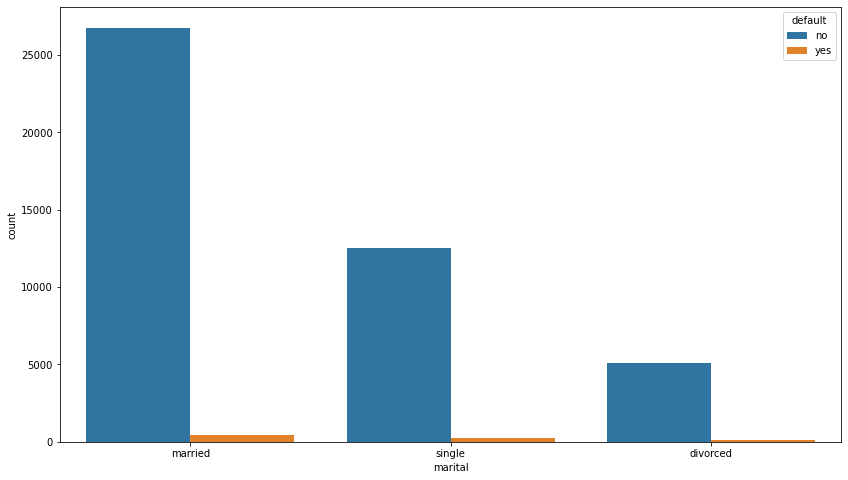

```python
sns.countplot(x="marital",data=data,hue="default")
```

#### Marital - Housing Loan

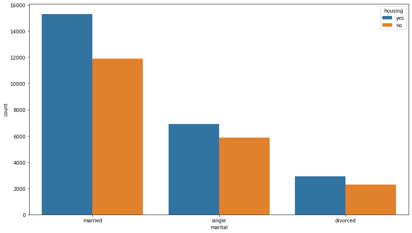

```python
sns.countplot(x="marital",data=data,hue="housing")
```

#### Marital - Personal Loan

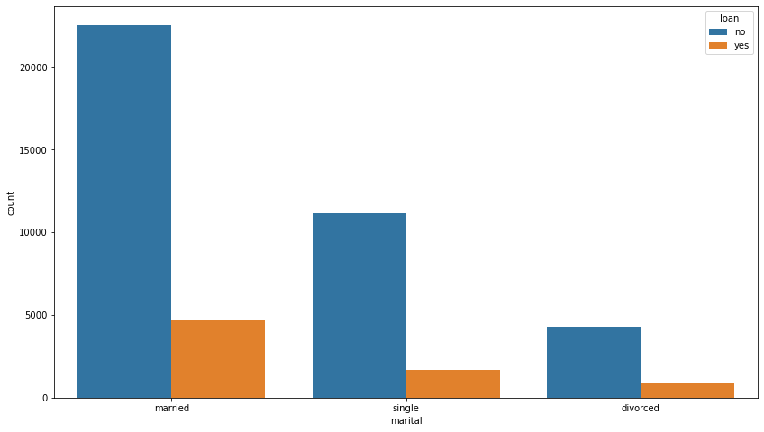

```python
sns.countplot(x="marital",data=data,hue="loan")
```

#### Marital - Target Variable

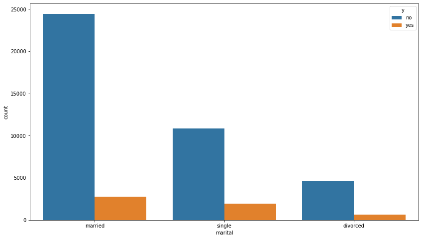

```python
sns.countplot(x="marital",data=data,hue="y")
```

### *It is also clear that mostly all marital class haven't subscribed to term deposit*

#### Education - Default

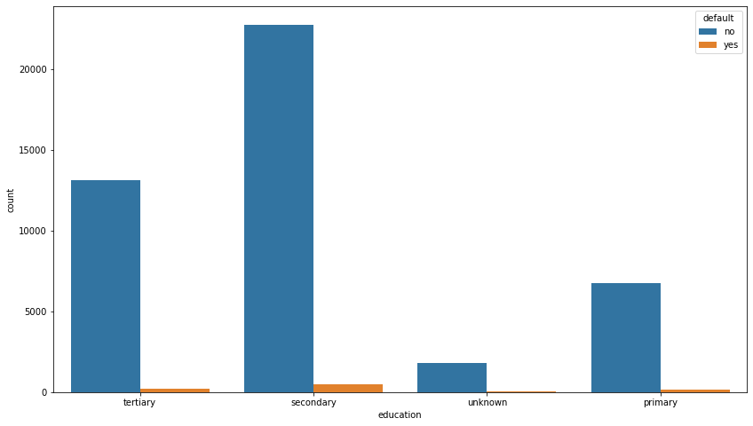

```python
sns.countplot(x="education",data=data,hue="default")
```

#### Education - Housing

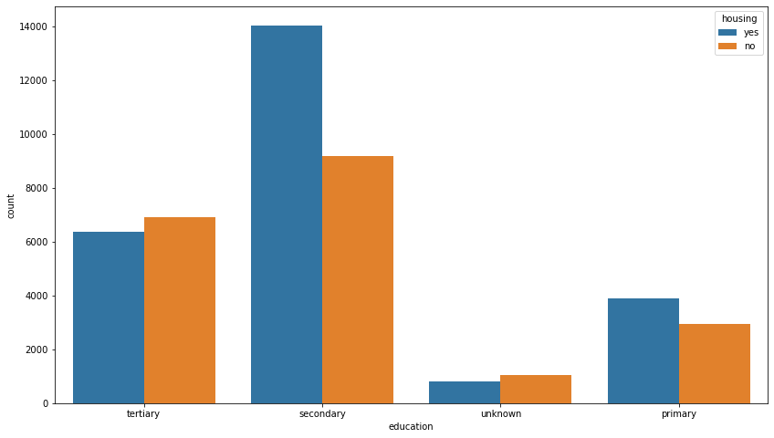

```python
sns.countplot(x="education",data=data,hue="housing")
```

#### Education - Personal Loan

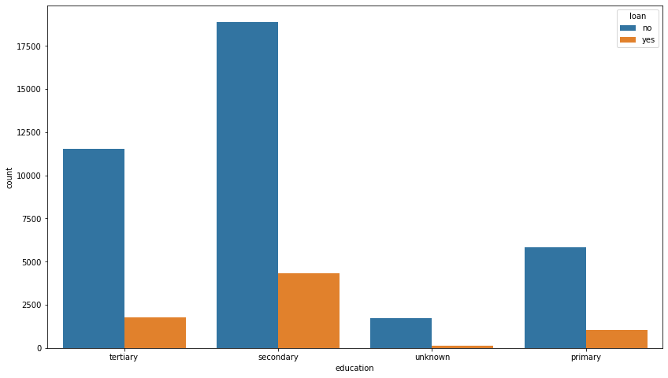

```python
sns.countplot(x="education",data=data,hue="loan")
```

#### Education - Target Variable

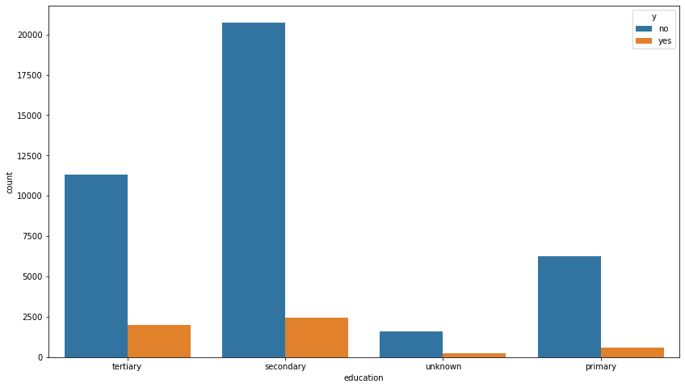

```python
plt.figure(figsize=(14,8))
sns.countplot(x="education",data=data,hue="y")
```

### *It is also clear that mostly all educated class haven't subscribed to term deposit*

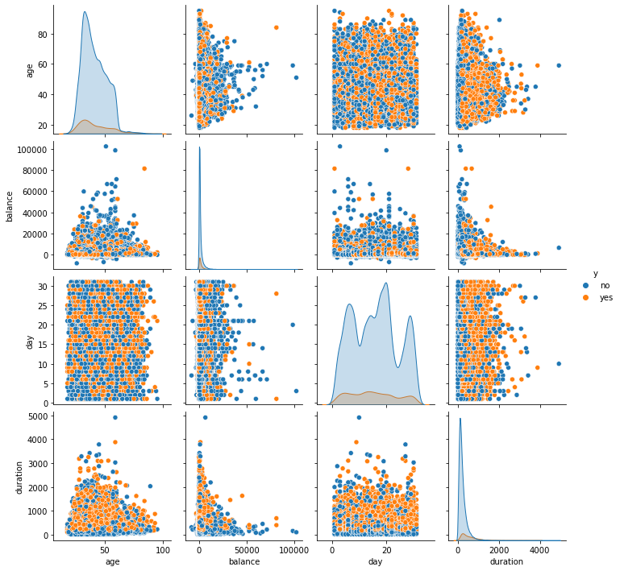

```python
sns.pairplot(data=data,hue="y",vars=['age','balance','day','duration'])
```

### Correlation Mapping

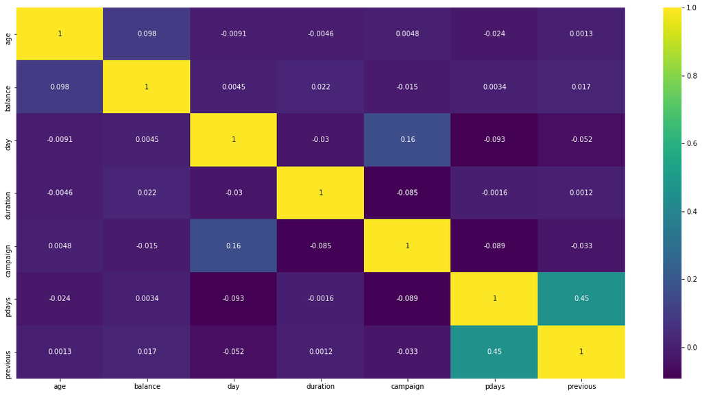

```python
plt.figure(figsize=(20,10))
sns.heatmap(data=data.corr(), annot=True, cmap='viridis')
```

### Correlation between variables is very less, which could possibly be due to presence of many outliers, so we will apply Transformations

## Checking Outliers in Continuous Variables

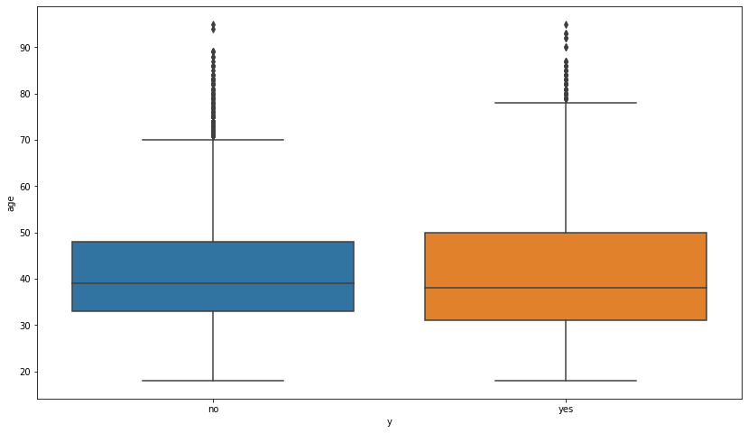

```python
sns.boxplot(x="y",y="age",data=data)
```

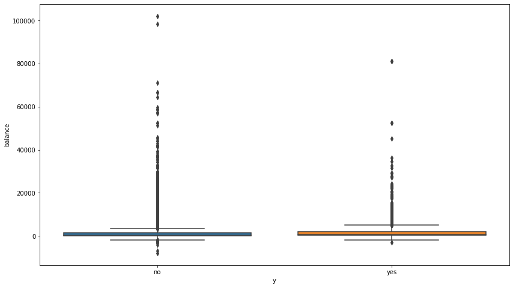

```python
sns.boxplot(x="y",y="balance",data=data)
```

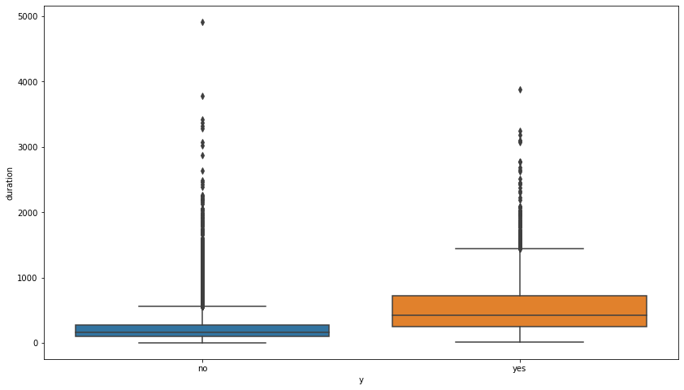

```python
sns.boxplot(x="y",y="duration",data=data)
```

### Applying Transformation

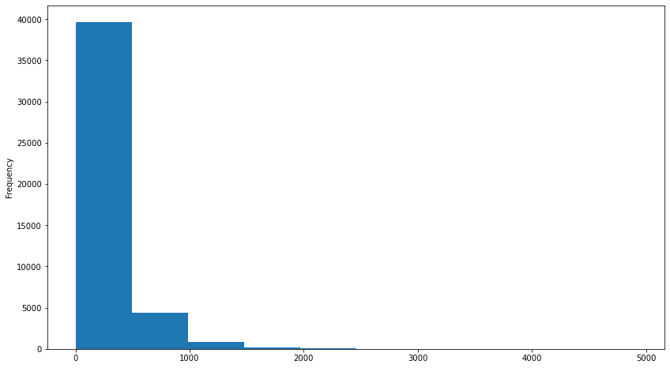

```python
data['duration'].plot.hist()
```

```python
from sklearn.preprocessing import PowerTransformer
b = data.drop(['job','marital','education','default','campaign','housing','loan','contact','month','previous','poutcome','y'],axis=1)
b
```

|  | age | balance | day | duration | pdays |
| --- | --- | --- | --- | --- | --- |
| 0 | 58 | 2143 | 5 | 261 | -1 |
| 1 | 44 | 29 | 5 | 151 | -1 |
| 2 | 33 | 2 | 5 | 76 | -1 |
| 3 | 47 | 1506 | 5 | 92 | -1 |
| 4 | 33 | 1 | 5 | 198 | -1 |
| ... | ... | ... | ... | ... | ... |
| 45206 | 51 | 825 | 17 | 977 | -1 |
| 45207 | 71 | 1729 | 17 | 456 | -1 |
| 45208 | 72 | 5715 | 17 | 1127 | 184 |
| 45209 | 57 | 668 | 17 | 508 | -1 |
| 45210 | 37 | 2971 | 17 | 361 | 188 |

45211 rows × 5 columns

```python
pt = PowerTransformer(method='yeo-johnson', standardize=True)
skl_yeojohnson = pt.fit(b)
calc_lambdas = skl_yeojohnson.lambdas_
skl_yeojohnson = pt.transform(b)
df_ptdata = pd.DataFrame(data=skl_yeojohnson, columns=['Age','Balance','Day','Duration','Pdays'])
df_ptdata.head()
```

|  | Age | Balance | Day | Duration | Pdays |
| --- | --- | --- | --- | --- | --- |
| 0 | 1.473637 | 0.414773 | -1.351873 | 0.386077 | -0.472533 |
| 1 | 0.429379 | -0.410774 | -1.351873 | -0.223033 | -0.472533 |
| 2 | -0.709873 | -0.431122 | -1.351873 | -0.923854 | -0.472533 |
| 3 | 0.683128 | 0.197685 | -1.351873 | -0.735678 | -0.472533 |
| 4 | -0.709873 | -0.432119 | -1.351873 | 0.072812 | -0.472533 |

### After Treatment data is tending towards normal distributed

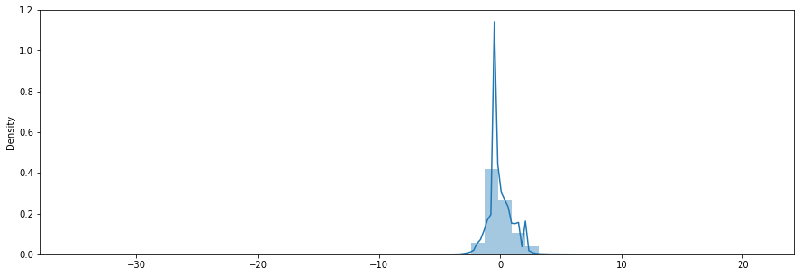

```python
import warnings
warnings.filterwarnings("ignore")
plt.figure(figsize=(15,5))
sns.distplot(df_ptdata)
```

### Before Treatment Data was Right Skewed

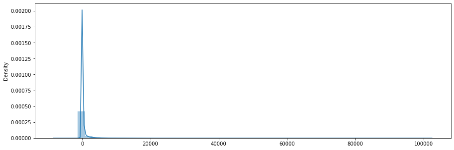

```python
plt.figure(figsize=(15,5))
sns.distplot(b)
```

### By doing Transformation in 5 Columns most of data are now treated

```python
DATA = pd.concat([df_ptdata,data],axis=1)
```

```python
DATA
```

|  | Age | Balance | Day | Duration | Pdays | age | job | marital | education | default | ... | loan | contact | day | month | duration | campaign | pdays | previous | poutcome | y |
| --- | --- | --- | --- | --- | --- | --- | --- | --- | --- | --- | --- | --- | --- | --- | --- | --- | --- | --- | --- | --- | --- |
| 0 | 1.473637 | 0.414773 | -1.351873 | 0.386077 | -0.472533 | 58 | management | married | tertiary | no | ... | no | unknown | 5 | may | 261 | 1 | -1 | 0 | unknown | no |
| 1 | 0.429379 | -0.410774 | -1.351873 | -0.223033 | -0.472533 | 44 | technician | single | secondary | no | ... | no | unknown | 5 | may | 151 | 1 | -1 | 0 | unknown | no |
| 2 | -0.709873 | -0.431122 | -1.351873 | -0.923854 | -0.472533 | 33 | entrepreneur | married | secondary | no | ... | yes | unknown | 5 | may | 76 | 1 | -1 | 0 | unknown | no |
| 3 | 0.683128 | 0.197685 | -1.351873 | -0.735678 | -0.472533 | 47 | blue-collar | married | unknown | no | ... | no | unknown | 5 | may | 92 | 1 | -1 | 0 | unknown | no |
| 4 | -0.709873 | -0.432119 | -1.351873 | 0.072812 | -0.472533 | 33 | unknown | single | unknown | no | ... | no | unknown | 5 | may | 198 | 1 | -1 | 0 | unknown | no |
| ... | ... | ... | ... | ... | ... | ... | ... | ... | ... | ... | ... | ... | ... | ... | ... | ... | ... | ... | ... | ... | ... |
| 45206 | 0.993503 | -0.052398 | 0.220403 | 2.057767 | -0.472533 | 51 | technician | married | tertiary | no | ... | no | cellular | 17 | nov | 977 | 3 | -1 | 0 | unknown | yes |
| 45207 | 2.207438 | 0.275122 | 0.220403 | 1.056254 | -0.472533 | 71 | retired | divorced | primary | no | ... | no | cellular | 17 | nov | 456 | 2 | -1 | 0 | unknown | yes |
| 45208 | 2.257237 | 1.495765 | 0.220403 | 2.257271 | 2.122381 | 72 | retired | married | secondary | no | ... | no | cellular | 17 | nov | 1127 | 5 | 184 | 3 | success | yes |
| 45209 | 1.409327 | -0.114235 | 0.220403 | 1.191963 | -0.472533 | 57 | blue-collar | married | secondary | no | ... | no | telephone | 17 | nov | 508 | 4 | -1 | 0 | unknown | no |
| 45210 | -0.250469 | 0.681838 | 0.220403 | 0.769421 | 2.123051 | 37 | entrepreneur | married | secondary | no | ... | no | cellular | 17 | nov | 361 | 2 | 188 | 11 | other | no |

45211 rows × 22 columns

#### Replacing Treated Variables with original data

```python
c = DATA.drop(['age','balance','day','duration','pdays'],axis=1)
c
```

|  | Age | Balance | Day | Duration | Pdays | job | marital | education | default | housing | loan | contact | month | campaign | previous | poutcome | y |
| --- | --- | --- | --- | --- | --- | --- | --- | --- | --- | --- | --- | --- | --- | --- | --- | --- | --- |
| 0 | 1.473637 | 0.414773 | -1.351873 | 0.386077 | -0.472533 | management | married | tertiary | no | yes | no | unknown | may | 1 | 0 | unknown | no |
| 1 | 0.429379 | -0.410774 | -1.351873 | -0.223033 | -0.472533 | technician | single | secondary | no | yes | no | unknown | may | 1 | 0 | unknown | no |
| 2 | -0.709873 | -0.431122 | -1.351873 | -0.923854 | -0.472533 | entrepreneur | married | secondary | no | yes | yes | unknown | may | 1 | 0 | unknown | no |
| 3 | 0.683128 | 0.197685 | -1.351873 | -0.735678 | -0.472533 | blue-collar | married | unknown | no | yes | no | unknown | may | 1 | 0 | unknown | no |
| 4 | -0.709873 | -0.432119 | -1.351873 | 0.072812 | -0.472533 | unknown | single | unknown | no | no | no | unknown | may | 1 | 0 | unknown | no |
| ... | ... | ... | ... | ... | ... | ... | ... | ... | ... | ... | ... | ... | ... | ... | ... | ... | ... |
| 45206 | 0.993503 | -0.052398 | 0.220403 | 2.057767 | -0.472533 | technician | married | tertiary | no | no | no | cellular | nov | 3 | 0 | unknown | yes |
| 45207 | 2.207438 | 0.275122 | 0.220403 | 1.056254 | -0.472533 | retired | divorced | primary | no | no | no | cellular | nov | 2 | 0 | unknown | yes |
| 45208 | 2.257237 | 1.495765 | 0.220403 | 2.257271 | 2.122381 | retired | married | secondary | no | no | no | cellular | nov | 5 | 3 | success | yes |
| 45209 | 1.409327 | -0.114235 | 0.220403 | 1.191963 | -0.472533 | blue-collar | married | secondary | no | no | no | telephone | nov | 4 | 0 | unknown | no |
| 45210 | -0.250469 | 0.681838 | 0.220403 | 0.769421 | 2.123051 | entrepreneur | married | secondary | no | no | no | cellular | nov | 2 | 11 | other | no |

45211 rows × 17 columns

### LABEL ENCODING on Certain Ordinal Data

```python
label_encoder = preprocessing.LabelEncoder()
```

```python
data['Job']= label_encoder.fit_transform(data['job'])
```

```python
data['Marital']= label_encoder.fit_transform(data['marital'])
```

```python
data['Education']= label_encoder.fit_transform(data['education'])
```

```python
data['Month']= label_encoder.fit_transform(data['month'])
```

```python
data['y1']= label_encoder.fit_transform(data['y'])
data
```

|  | age | job | marital | education | default | balance | housing | loan | contact | day | ... | campaign | pdays | previous | poutcome | y | Job | Marital | Education | Month | y1 |
| --- | --- | --- | --- | --- | --- | --- | --- | --- | --- | --- | --- | --- | --- | --- | --- | --- | --- | --- | --- | --- | --- |
| 0 | 58 | management | married | tertiary | no | 2143 | yes | no | unknown | 5 | ... | 1 | -1 | 0 | unknown | no | 4 | 1 | 2 | 8 | 0 |
| 1 | 44 | technician | single | secondary | no | 29 | yes | no | unknown | 5 | ... | 1 | -1 | 0 | unknown | no | 9 | 2 | 1 | 8 | 0 |
| 2 | 33 | entrepreneur | married | secondary | no | 2 | yes | yes | unknown | 5 | ... | 1 | -1 | 0 | unknown | no | 2 | 1 | 1 | 8 | 0 |
| 3 | 47 | blue-collar | married | unknown | no | 1506 | yes | no | unknown | 5 | ... | 1 | -1 | 0 | unknown | no | 1 | 1 | 3 | 8 | 0 |
| 4 | 33 | unknown | single | unknown | no | 1 | no | no | unknown | 5 | ... | 1 | -1 | 0 | unknown | no | 11 | 2 | 3 | 8 | 0 |
| ... | ... | ... | ... | ... | ... | ... | ... | ... | ... | ... | ... | ... | ... | ... | ... | ... | ... | ... | ... | ... | ... |
| 45206 | 51 | technician | married | tertiary | no | 825 | no | no | cellular | 17 | ... | 3 | -1 | 0 | unknown | yes | 9 | 1 | 2 | 9 | 1 |
| 45207 | 71 | retired | divorced | primary | no | 1729 | no | no | cellular | 17 | ... | 2 | -1 | 0 | unknown | yes | 5 | 0 | 0 | 9 | 1 |
| 45208 | 72 | retired | married | secondary | no | 5715 | no | no | cellular | 17 | ... | 5 | 184 | 3 | success | yes | 5 | 1 | 1 | 9 | 1 |
| 45209 | 57 | blue-collar | married | secondary | no | 668 | no | no | telephone | 17 | ... | 4 | -1 | 0 | unknown | no | 1 | 1 | 1 | 9 | 0 |
| 45210 | 37 | entrepreneur | married | secondary | no | 2971 | no | no | cellular | 17 | ... | 2 | 188 | 11 | other | no | 2 | 1 | 1 | 9 | 0 |

45211 rows × 22 columns

```python
label_data=data.drop(['age','job','marital','education','default','balance','housing','loan','contact','day','duration','campaign','pdays','previous','poutcome','y','month'],axis=1)
label_data
```

|  | Job | Marital | Education | Month | y1 |
| --- | --- | --- | --- | --- | --- |
| 0 | 4 | 1 | 2 | 8 | 0 |
| 1 | 9 | 2 | 1 | 8 | 0 |
| 2 | 2 | 1 | 1 | 8 | 0 |
| 3 | 1 | 1 | 3 | 8 | 0 |
| 4 | 11 | 2 | 3 | 8 | 0 |
| ... | ... | ... | ... | ... | ... |
| 45206 | 9 | 1 | 2 | 9 | 1 |
| 45207 | 5 | 0 | 0 | 9 | 1 |
| 45208 | 5 | 1 | 1 | 9 | 1 |
| 45209 | 1 | 1 | 1 | 9 | 0 |
| 45210 | 2 | 1 | 1 | 9 | 0 |

45211 rows × 5 columns

### ONE HOT ENCODING on certain non-ordinal variables

```python
Dummy_DATA = pd.get_dummies(c,columns=['default','housing','loan','contact','poutcome'])
Dummy_DATA
```

|  | Age | Balance | Day | Duration | Pdays | job | marital | education | month | campaign | ... | housing_yes | loan_no | loan_yes | contact_cellular | contact_telephone | contact_unknown | poutcome_failure | poutcome_other | poutcome_success | poutcome_unknown |
| --- | --- | --- | --- | --- | --- | --- | --- | --- | --- | --- | --- | --- | --- | --- | --- | --- | --- | --- | --- | --- | --- |
| 0 | 1.473637 | 0.414773 | -1.351873 | 0.386077 | -0.472533 | management | married | tertiary | may | 1 | ... | 1 | 1 | 0 | 0 | 0 | 1 | 0 | 0 | 0 | 1 |
| 1 | 0.429379 | -0.410774 | -1.351873 | -0.223033 | -0.472533 | technician | single | secondary | may | 1 | ... | 1 | 1 | 0 | 0 | 0 | 1 | 0 | 0 | 0 | 1 |
| 2 | -0.709873 | -0.431122 | -1.351873 | -0.923854 | -0.472533 | entrepreneur | married | secondary | may | 1 | ... | 1 | 0 | 1 | 0 | 0 | 1 | 0 | 0 | 0 | 1 |
| 3 | 0.683128 | 0.197685 | -1.351873 | -0.735678 | -0.472533 | blue-collar | married | unknown | may | 1 | ... | 1 | 1 | 0 | 0 | 0 | 1 | 0 | 0 | 0 | 1 |
| 4 | -0.709873 | -0.432119 | -1.351873 | 0.072812 | -0.472533 | unknown | single | unknown | may | 1 | ... | 0 | 1 | 0 | 0 | 0 | 1 | 0 | 0 | 0 | 1 |
| ... | ... | ... | ... | ... | ... | ... | ... | ... | ... | ... | ... | ... | ... | ... | ... | ... | ... | ... | ... | ... | ... |
| 45206 | 0.993503 | -0.052398 | 0.220403 | 2.057767 | -0.472533 | technician | married | tertiary | nov | 3 | ... | 0 | 1 | 0 | 1 | 0 | 0 | 0 | 0 | 0 | 1 |
| 45207 | 2.207438 | 0.275122 | 0.220403 | 1.056254 | -0.472533 | retired | divorced | primary | nov | 2 | ... | 0 | 1 | 0 | 1 | 0 | 0 | 0 | 0 | 0 | 1 |
| 45208 | 2.257237 | 1.495765 | 0.220403 | 2.257271 | 2.122381 | retired | married | secondary | nov | 5 | ... | 0 | 1 | 0 | 1 | 0 | 0 | 0 | 0 | 1 | 0 |
| 45209 | 1.409327 | -0.114235 | 0.220403 | 1.191963 | -0.472533 | blue-collar | married | secondary | nov | 4 | ... | 0 | 1 | 0 | 0 | 1 | 0 | 0 | 0 | 0 | 1 |
| 45210 | -0.250469 | 0.681838 | 0.220403 | 0.769421 | 2.123051 | entrepreneur | married | secondary | nov | 2 | ... | 0 | 1 | 0 | 1 | 0 | 0 | 0 | 1 | 0 | 0 |

45211 rows × 25 columns

```python
Dummy_Variables = Dummy_DATA.drop(['Age','Balance','Day','Duration','Pdays','job','marital','education','month','campaign','y','previous'],axis=1)
Dummy_Variables
```

|  | default_no | default_yes | housing_no | housing_yes | loan_no | loan_yes | contact_cellular | contact_telephone | contact_unknown | poutcome_failure | poutcome_other | poutcome_success | poutcome_unknown |
| --- | --- | --- | --- | --- | --- | --- | --- | --- | --- | --- | --- | --- | --- |
| 0 | 1 | 0 | 0 | 1 | 1 | 0 | 0 | 0 | 1 | 0 | 0 | 0 | 1 |
| 1 | 1 | 0 | 0 | 1 | 1 | 0 | 0 | 0 | 1 | 0 | 0 | 0 | 1 |
| 2 | 1 | 0 | 0 | 1 | 0 | 1 | 0 | 0 | 1 | 0 | 0 | 0 | 1 |
| 3 | 1 | 0 | 0 | 1 | 1 | 0 | 0 | 0 | 1 | 0 | 0 | 0 | 1 |
| 4 | 1 | 0 | 1 | 0 | 1 | 0 | 0 | 0 | 1 | 0 | 0 | 0 | 1 |
| ... | ... | ... | ... | ... | ... | ... | ... | ... | ... | ... | ... | ... | ... |
| 45206 | 1 | 0 | 1 | 0 | 1 | 0 | 1 | 0 | 0 | 0 | 0 | 0 | 1 |
| 45207 | 1 | 0 | 1 | 0 | 1 | 0 | 1 | 0 | 0 | 0 | 0 | 0 | 1 |
| 45208 | 1 | 0 | 1 | 0 | 1 | 0 | 1 | 0 | 0 | 0 | 0 | 1 | 0 |
| 45209 | 1 | 0 | 1 | 0 | 1 | 0 | 0 | 1 | 0 | 0 | 0 | 0 | 1 |
| 45210 | 1 | 0 | 1 | 0 | 1 | 0 | 1 | 0 | 0 | 0 | 1 | 0 | 0 |

45211 rows × 13 columns

```python
Nondummy_DATA = Dummy_DATA.drop(['default_no','default_yes','housing_no','housing_yes','loan_no','loan_yes','contact_cellular','contact_telephone','contact_unknown','poutcome_failure','poutcome_other','poutcome_success','poutcome_unknown'],axis=1)
Nondummy_DATA
```

|  | Age | Balance | Day | Duration | Pdays | job | marital | education | month | campaign | previous | y |
| --- | --- | --- | --- | --- | --- | --- | --- | --- | --- | --- | --- | --- |
| 0 | 1.473637 | 0.414773 | -1.351873 | 0.386077 | -0.472533 | management | married | tertiary | may | 1 | 0 | no |
| 1 | 0.429379 | -0.410774 | -1.351873 | -0.223033 | -0.472533 | technician | single | secondary | may | 1 | 0 | no |
| 2 | -0.709873 | -0.431122 | -1.351873 | -0.923854 | -0.472533 | entrepreneur | married | secondary | may | 1 | 0 | no |
| 3 | 0.683128 | 0.197685 | -1.351873 | -0.735678 | -0.472533 | blue-collar | married | unknown | may | 1 | 0 | no |
| 4 | -0.709873 | -0.432119 | -1.351873 | 0.072812 | -0.472533 | unknown | single | unknown | may | 1 | 0 | no |
| ... | ... | ... | ... | ... | ... | ... | ... | ... | ... | ... | ... | ... |
| 45206 | 0.993503 | -0.052398 | 0.220403 | 2.057767 | -0.472533 | technician | married | tertiary | nov | 3 | 0 | yes |
| 45207 | 2.207438 | 0.275122 | 0.220403 | 1.056254 | -0.472533 | retired | divorced | primary | nov | 2 | 0 | yes |
| 45208 | 2.257237 | 1.495765 | 0.220403 | 2.257271 | 2.122381 | retired | married | secondary | nov | 5 | 3 | yes |
| 45209 | 1.409327 | -0.114235 | 0.220403 | 1.191963 | -0.472533 | blue-collar | married | secondary | nov | 4 | 0 | no |
| 45210 | -0.250469 | 0.681838 | 0.220403 | 0.769421 | 2.123051 | entrepreneur | married | secondary | nov | 2 | 11 | no |

45211 rows × 12 columns

```python
final_data=pd.concat([Dummy_Variables,Nondummy_DATA,label_data],axis=1)
final_data
```

|  | default_no | default_yes | housing_no | housing_yes | loan_no | loan_yes | contact_cellular | contact_telephone | contact_unknown | poutcome_failure | ... | education | month | campaign | previous | y | Job | Marital | Education | Month | y1 |
| --- | --- | --- | --- | --- | --- | --- | --- | --- | --- | --- | --- | --- | --- | --- | --- | --- | --- | --- | --- | --- | --- |
| 0 | 1 | 0 | 0 | 1 | 1 | 0 | 0 | 0 | 1 | 0 | ... | tertiary | may | 1 | 0 | no | 4 | 1 | 2 | 8 | 0 |
| 1 | 1 | 0 | 0 | 1 | 1 | 0 | 0 | 0 | 1 | 0 | ... | secondary | may | 1 | 0 | no | 9 | 2 | 1 | 8 | 0 |
| 2 | 1 | 0 | 0 | 1 | 0 | 1 | 0 | 0 | 1 | 0 | ... | secondary | may | 1 | 0 | no | 2 | 1 | 1 | 8 | 0 |
| 3 | 1 | 0 | 0 | 1 | 1 | 0 | 0 | 0 | 1 | 0 | ... | unknown | may | 1 | 0 | no | 1 | 1 | 3 | 8 | 0 |
| 4 | 1 | 0 | 1 | 0 | 1 | 0 | 0 | 0 | 1 | 0 | ... | unknown | may | 1 | 0 | no | 11 | 2 | 3 | 8 | 0 |
| ... | ... | ... | ... | ... | ... | ... | ... | ... | ... | ... | ... | ... | ... | ... | ... | ... | ... | ... | ... | ... | ... |
| 45206 | 1 | 0 | 1 | 0 | 1 | 0 | 1 | 0 | 0 | 0 | ... | tertiary | nov | 3 | 0 | yes | 9 | 1 | 2 | 9 | 1 |
| 45207 | 1 | 0 | 1 | 0 | 1 | 0 | 1 | 0 | 0 | 0 | ... | primary | nov | 2 | 0 | yes | 5 | 0 | 0 | 9 | 1 |
| 45208 | 1 | 0 | 1 | 0 | 1 | 0 | 1 | 0 | 0 | 0 | ... | secondary | nov | 5 | 3 | yes | 5 | 1 | 1 | 9 | 1 |
| 45209 | 1 | 0 | 1 | 0 | 1 | 0 | 0 | 1 | 0 | 0 | ... | secondary | nov | 4 | 0 | no | 1 | 1 | 1 | 9 | 0 |
| 45210 | 1 | 0 | 1 | 0 | 1 | 0 | 1 | 0 | 0 | 0 | ... | secondary | nov | 2 | 11 | no | 2 | 1 | 1 | 9 | 0 |

45211 rows × 30 columns

```python
final_data.shape
```

```
(45211, 30)
```

```python
final_cleaned_data=final_data.drop(['job', 'marital', 'education', 'month','y'],axis=1)
final_cleaned_data.shape
```

```
(45211, 25)
```

```python
final_cleaned_data.columns
```

```
Index(['default_no', 'default_yes', 'housing_no', 'housing_yes', 'loan_no',
       'loan_yes', 'contact_cellular', 'contact_telephone', 'contact_unknown',
       'poutcome_failure', 'poutcome_other', 'poutcome_success',
       'poutcome_unknown', 'Age', 'Balance', 'Day', 'Duration', 'Pdays',
       'campaign', 'previous', 'Job', 'Marital', 'Education', 'Month', 'y1'],
      dtype='object')
```

### Our Model is to be built with 25 Columns where 5 Columns undergo One Hot Encoding and 4 Columns undergo Label Encoding

```python
X = final_cleaned_data.iloc[:,:-1]
```

```python
Y = final_cleaned_data.iloc[:,-1]
```

```python
X_train,X_test,y_train,y_test = train_test_split(X,Y,test_size = 0.2,random_state = 42)
```

```python
classifier = LogisticRegression()
```

```python
classifier.fit(X_train,y_train)
```

```
LogisticRegression()
```

```python
classifier.coef_
```

```
array([[-0.36718628, -0.63430664, -0.05936716, -0.94212577, -0.22002574,
        -0.78146718,  0.04145533,  0.12875498, -1.17170323, -0.92854988,
        -0.65964438,  1.3838008 , -0.79709946, -0.03512548,  0.07645336,
        -0.03411812,  1.50154004,  0.17829372, -0.08128971,  0.00596699,
         0.00368797,  0.11453786,  0.15654382,  0.02553291]])
```

```python
classifier.predict_proba(X_test)
```

```
array([[0.98568775, 0.01431225],
       [0.98978639, 0.01021361],
       [0.93095263, 0.06904737],
       ...,
       [0.98695822, 0.01304178],
       [0.99439285, 0.00560715],
       [0.97446139, 0.02553861]])
```

```python
y_pred=classifier.predict(X)
final_cleaned_data["y_pred"]=y_pred
final_cleaned_data
```

|  | default_no | default_yes | housing_no | housing_yes | loan_no | loan_yes | contact_cellular | contact_telephone | contact_unknown | poutcome_failure | ... | Duration | Pdays | campaign | previous | Job | Marital | Education | Month | y1 | y_pred |
| --- | --- | --- | --- | --- | --- | --- | --- | --- | --- | --- | --- | --- | --- | --- | --- | --- | --- | --- | --- | --- | --- |
| 0 | 1 | 0 | 0 | 1 | 1 | 0 | 0 | 0 | 1 | 0 | ... | 0.386077 | -0.472533 | 1 | 0 | 4 | 1 | 2 | 8 | 0 | 0 |
| 1 | 1 | 0 | 0 | 1 | 1 | 0 | 0 | 0 | 1 | 0 | ... | -0.223033 | -0.472533 | 1 | 0 | 9 | 2 | 1 | 8 | 0 | 0 |
| 2 | 1 | 0 | 0 | 1 | 0 | 1 | 0 | 0 | 1 | 0 | ... | -0.923854 | -0.472533 | 1 | 0 | 2 | 1 | 1 | 8 | 0 | 0 |
| 3 | 1 | 0 | 0 | 1 | 1 | 0 | 0 | 0 | 1 | 0 | ... | -0.735678 | -0.472533 | 1 | 0 | 1 | 1 | 3 | 8 | 0 | 0 |
| 4 | 1 | 0 | 1 | 0 | 1 | 0 | 0 | 0 | 1 | 0 | ... | 0.072812 | -0.472533 | 1 | 0 | 11 | 2 | 3 | 8 | 0 | 0 |
| ... | ... | ... | ... | ... | ... | ... | ... | ... | ... | ... | ... | ... | ... | ... | ... | ... | ... | ... | ... | ... | ... |
| 45206 | 1 | 0 | 1 | 0 | 1 | 0 | 1 | 0 | 0 | 0 | ... | 2.057767 | -0.472533 | 3 | 0 | 9 | 1 | 2 | 9 | 1 | 1 |
| 45207 | 1 | 0 | 1 | 0 | 1 | 0 | 1 | 0 | 0 | 0 | ... | 1.056254 | -0.472533 | 2 | 0 | 5 | 0 | 0 | 9 | 1 | 0 |
| 45208 | 1 | 0 | 1 | 0 | 1 | 0 | 1 | 0 | 0 | 0 | ... | 2.257271 | 2.122381 | 5 | 3 | 5 | 1 | 1 | 9 | 1 | 1 |
| 45209 | 1 | 0 | 1 | 0 | 1 | 0 | 0 | 1 | 0 | 0 | ... | 1.191963 | -0.472533 | 4 | 0 | 1 | 1 | 1 | 9 | 0 | 0 |
| 45210 | 1 | 0 | 1 | 0 | 1 | 0 | 1 | 0 | 0 | 0 | ... | 0.769421 | 2.123051 | 2 | 11 | 2 | 1 | 1 | 9 | 0 | 0 |

45211 rows × 26 columns

```python
y_prob = pd.DataFrame(classifier.predict_proba(X.iloc[:,:]))
```

```python
new_df = pd.concat([final_cleaned_data,y_prob],axis=1)
new_df
```

|  | default_no | default_yes | housing_no | housing_yes | loan_no | loan_yes | contact_cellular | contact_telephone | contact_unknown | poutcome_failure | ... | campaign | previous | Job | Marital | Education | Month | y1 | y_pred | 0 | 1 |
| --- | --- | --- | --- | --- | --- | --- | --- | --- | --- | --- | --- | --- | --- | --- | --- | --- | --- | --- | --- | --- | --- |
| 0 | 1 | 0 | 0 | 1 | 1 | 0 | 0 | 0 | 1 | 0 | ... | 1 | 0 | 4 | 1 | 2 | 8 | 0 | 0 | 0.970681 | 0.029319 |
| 1 | 1 | 0 | 0 | 1 | 1 | 0 | 0 | 0 | 1 | 0 | ... | 1 | 0 | 9 | 2 | 1 | 8 | 0 | 0 | 0.988619 | 0.011381 |
| 2 | 1 | 0 | 0 | 1 | 0 | 1 | 0 | 0 | 1 | 0 | ... | 1 | 0 | 2 | 1 | 1 | 8 | 0 | 0 | 0.997934 | 0.002066 |
| 3 | 1 | 0 | 0 | 1 | 1 | 0 | 0 | 0 | 1 | 0 | ... | 1 | 0 | 1 | 1 | 3 | 8 | 0 | 0 | 0.993487 | 0.006513 |
| 4 | 1 | 0 | 1 | 0 | 1 | 0 | 0 | 0 | 1 | 0 | ... | 1 | 0 | 11 | 2 | 3 | 8 | 0 | 0 | 0.941505 | 0.058495 |
| ... | ... | ... | ... | ... | ... | ... | ... | ... | ... | ... | ... | ... | ... | ... | ... | ... | ... | ... | ... | ... | ... |
| 45206 | 1 | 0 | 1 | 0 | 1 | 0 | 1 | 0 | 0 | 0 | ... | 3 | 0 | 9 | 1 | 2 | 9 | 1 | 1 | 0.285946 | 0.714054 |
| 45207 | 1 | 0 | 1 | 0 | 1 | 0 | 1 | 0 | 0 | 0 | ... | 2 | 0 | 5 | 0 | 0 | 9 | 1 | 0 | 0.724590 | 0.275410 |
| 45208 | 1 | 0 | 1 | 0 | 1 | 0 | 1 | 0 | 0 | 0 | ... | 5 | 3 | 5 | 1 | 1 | 9 | 1 | 1 | 0.026179 | 0.973821 |
| 45209 | 1 | 0 | 1 | 0 | 1 | 0 | 0 | 1 | 0 | 0 | ... | 4 | 0 | 1 | 1 | 1 | 9 | 0 | 0 | 0.642047 | 0.357953 |
| 45210 | 1 | 0 | 1 | 0 | 1 | 0 | 1 | 0 | 0 | 0 | ... | 2 | 11 | 2 | 1 | 1 | 9 | 0 | 0 | 0.587762 | 0.412238 |

45211 rows × 28 columns

```python
pd.crosstab(Y,y_pred)
```

| col_0 y1 | 0 | 1 |
| --- | --- | --- |
| 0 | 38963 | 959 |
| 1 | 3565 | 1724 |

```python
print(classification_report(Y,y_pred))
```

```
              precision    recall  f1-score   support

           0       0.92      0.98      0.95     39922
           1       0.64      0.33      0.43      5289

    accuracy                           0.90     45211
   macro avg       0.78      0.65      0.69     45211
weighted avg       0.88      0.90      0.89     45211
```

```python
logit_roc_score = roc_auc_score(Y,classifier.predict(X))
```

```python
logit_roc_score
```

```
0.6509688480360488
```

```python
logit = sm.Logit(Y,X)
```

```python
logit.fit().summary()
```

Logit Regression Results

| Dep. Variable: | y1 | No. Observations: | 45211 |
| --- | --- | --- | --- |
| Model: | Logit | Df Residuals: | 45188 |
| Method: | MLE | Df Model: | 22 |
| Date: | Thu, 11 Mar 2021 | Pseudo R-squ.: | 0.3305 |
| Time: | 15:19:45 | Log-Likelihood: | -10923. |
| converged: | False | LL-Null: | -16315. |
| Covariance Type: | nonrobust | LLR p-value: | 0.000 |

|  | coef | std err | z | P>\|z\| | [0.025 | 0.975] |
| --- | --- | --- | --- | --- | --- | --- |
| default_no | -41.9740 | 1.04e+06 | -4.04e-05 | 1.000 | -2.04e+06 | 2.04e+06 |
| default_yes | -42.1583 | 1.04e+06 | -4.06e-05 | 1.000 | -2.04e+06 | 2.04e+06 |
| housing_no | 36.7712 | 6.65e+05 | 5.53e-05 | 1.000 | -1.3e+06 | 1.3e+06 |
| housing_yes | 35.8983 | 7.12e+05 | 5.04e-05 | 1.000 | -1.39e+06 | 1.39e+06 |
| loan_no | -0.3377 | 1.38e+06 | -2.45e-07 | 1.000 | -2.71e+06 | 2.71e+06 |
| loan_yes | -0.9115 | 1.4e+06 | -6.53e-07 | 1.000 | -2.74e+06 | 2.74e+06 |
| contact_cellular | 3.4565 | 7.72e+05 | 4.48e-06 | 1.000 | -1.51e+06 | 1.51e+06 |
| contact_telephone | 3.4858 | 7.69e+05 | 4.53e-06 | 1.000 | -1.51e+06 | 1.51e+06 |
| contact_unknown | 2.2862 | 7.83e+05 | 2.92e-06 | 1.000 | -1.54e+06 | 1.54e+06 |
| poutcome_failure | -1.3789 | 1.52e+06 | -9.09e-07 | 1.000 | -2.97e+06 | 2.97e+06 |
| poutcome_other | -1.1210 | 1.52e+06 | -7.39e-07 | 1.000 | -2.97e+06 | 2.97e+06 |
| poutcome_success | 0.9838 | 1.52e+06 | 6.49e-07 | 1.000 | -2.97e+06 | 2.97e+06 |
| poutcome_unknown | -0.2730 | 1.52e+06 | -1.8e-07 | 1.000 | -2.97e+06 | 2.97e+06 |
| Age | -0.0441 | 0.019 | -2.265 | 0.023 | -0.082 | -0.006 |
| Balance | 0.0855 | 0.017 | 4.971 | 0.000 | 0.052 | 0.119 |
| Day | -0.0442 | 0.018 | -2.476 | 0.013 | -0.079 | -0.009 |
| Duration | 1.4964 | 0.022 | 68.137 | 0.000 | 1.453 | 1.539 |
| Pdays | 0.5388 | 0.319 | 1.689 | 0.091 | -0.086 | 1.164 |
| campaign | -0.0849 | 0.010 | -8.517 | 0.000 | -0.104 | -0.065 |
| previous | 0.0086 | 0.006 | 1.331 | 0.183 | -0.004 | 0.021 |
| Job | 0.0052 | 0.006 | 0.936 | 0.349 | -0.006 | 0.016 |
| Marital | 0.1205 | 0.033 | 3.677 | 0.000 | 0.056 | 0.185 |
| Education | 0.1750 | 0.024 | 7.224 | 0.000 | 0.128 | 0.223 |
| Month | 0.0278 | 0.006 | 4.761 | 0.000 | 0.016 | 0.039 |

### It also seems that there is Imbalance data that needs to be treated

```python
!pip install imblearn
```

```python
# Implementing Undersampling for Handling Imbalanced
nm = NearMiss()
X_res,y_res=nm.fit_resample(X,Y)
```

```python
X_res.shape,y_res.shape
```

```
((10578, 24), (10578,))
```

```python
print('Original dataset shape {}'.format(Counter(Y)))
print('Resampled dataset shape {}'.format(Counter(y_res)))
```

```
Original dataset shape Counter({0: 39922, 1: 5289})
Resampled dataset shape Counter({0: 5289, 1: 5289})
```

```python
X_train,X_test,y_train,y_test = train_test_split(X_res,y_res,test_size = 0.2,random_state = 42)
```

```python
classifier = LogisticRegression()
classifier.fit(X_train,y_train)
classifier.coef_
```

```
array([[-1.53599744,  1.89642121,  0.510672  , -0.15024824, -0.515974  ,
         0.87639777, -0.44051608,  1.85892441, -1.05798456, -1.14110457,
         1.05885519,  0.58502482, -0.14235167,  0.04105996,  0.66257637,
        -0.06887198,  1.00756115,  0.98702817,  0.19387221,  0.46220331,
         0.06295518,  0.01499154,  0.15189875,  0.05861543]])
```

```python
classifier.predict_proba(X_test)
```

```
array([[0.17583083, 0.82416917],
       [0.3908622 , 0.6091378 ],
       [0.01657644, 0.98342356],
       ...,
       [0.42386963, 0.57613037],
       [0.01500844, 0.98499156],
       [0.317836  , 0.682164  ]])
```

```python
y_pred=classifier.predict(X)
final_cleaned_data["y_pred"]=y_pred
final_cleaned_data
```

|  | default_no | default_yes | housing_no | housing_yes | loan_no | loan_yes | contact_cellular | contact_telephone | contact_unknown | poutcome_failure | ... | Duration | Pdays | campaign | previous | Job | Marital | Education | Month | y1 | y_pred |
| --- | --- | --- | --- | --- | --- | --- | --- | --- | --- | --- | --- | --- | --- | --- | --- | --- | --- | --- | --- | --- | --- |
| 0 | 1 | 0 | 0 | 1 | 1 | 0 | 0 | 0 | 1 | 0 | ... | 0.386077 | -0.472533 | 1 | 0 | 4 | 1 | 2 | 8 | 0 | 0 |
| 1 | 1 | 0 | 0 | 1 | 1 | 0 | 0 | 0 | 1 | 0 | ... | -0.223033 | -0.472533 | 1 | 0 | 9 | 2 | 1 | 8 | 0 | 0 |
| 2 | 1 | 0 | 0 | 1 | 0 | 1 | 0 | 0 | 1 | 0 | ... | -0.923854 | -0.472533 | 1 | 0 | 2 | 1 | 1 | 8 | 0 | 0 |
| 3 | 1 | 0 | 0 | 1 | 1 | 0 | 0 | 0 | 1 | 0 | ... | -0.735678 | -0.472533 | 1 | 0 | 1 | 1 | 3 | 8 | 0 | 0 |
| 4 | 1 | 0 | 1 | 0 | 1 | 0 | 0 | 0 | 1 | 0 | ... | 0.072812 | -0.472533 | 1 | 0 | 11 | 2 | 3 | 8 | 0 | 0 |
| ... | ... | ... | ... | ... | ... | ... | ... | ... | ... | ... | ... | ... | ... | ... | ... | ... | ... | ... | ... | ... | ... |
| 45206 | 1 | 0 | 1 | 0 | 1 | 0 | 1 | 0 | 0 | 0 | ... | 2.057767 | -0.472533 | 3 | 0 | 9 | 1 | 2 | 9 | 1 | 1 |
| 45207 | 1 | 0 | 1 | 0 | 1 | 0 | 1 | 0 | 0 | 0 | ... | 1.056254 | -0.472533 | 2 | 0 | 5 | 0 | 0 | 9 | 1 | 1 |
| 45208 | 1 | 0 | 1 | 0 | 1 | 0 | 1 | 0 | 0 | 0 | ... | 2.257271 | 2.122381 | 5 | 3 | 5 | 1 | 1 | 9 | 1 | 1 |
| 45209 | 1 | 0 | 1 | 0 | 1 | 0 | 0 | 1 | 0 | 0 | ... | 1.191963 | -0.472533 | 4 | 0 | 1 | 1 | 1 | 9 | 0 | 1 |
| 45210 | 1 | 0 | 1 | 0 | 1 | 0 | 1 | 0 | 0 | 0 | ... | 0.769421 | 2.123051 | 2 | 11 | 2 | 1 | 1 | 9 | 0 | 1 |

45211 rows × 26 columns

```python
y_prob = pd.DataFrame(classifier.predict_proba(X.iloc[:,:]))
```

```python
new_df = pd.concat([final_cleaned_data,y_prob],axis=1)
new_df
```

|  | default_no | default_yes | housing_no | housing_yes | loan_no | loan_yes | contact_cellular | contact_telephone | contact_unknown | poutcome_failure | ... | campaign | previous | Job | Marital | Education | Month | y1 | y_pred | 0 | 1 |
| --- | --- | --- | --- | --- | --- | --- | --- | --- | --- | --- | --- | --- | --- | --- | --- | --- | --- | --- | --- | --- | --- |
| 0 | 1 | 0 | 0 | 1 | 1 | 0 | 0 | 0 | 1 | 0 | ... | 1 | 0 | 4 | 1 | 2 | 8 | 0 | 0 | 0.804688 | 0.195312 |
| 1 | 1 | 0 | 0 | 1 | 1 | 0 | 0 | 0 | 1 | 0 | ... | 1 | 0 | 9 | 2 | 1 | 8 | 0 | 0 | 0.919942 | 0.080058 |
| 2 | 1 | 0 | 0 | 1 | 0 | 1 | 0 | 0 | 1 | 0 | ... | 1 | 0 | 2 | 1 | 1 | 8 | 0 | 0 | 0.906468 | 0.093532 |
| 3 | 1 | 0 | 0 | 1 | 1 | 0 | 0 | 0 | 1 | 0 | ... | 1 | 0 | 1 | 1 | 3 | 8 | 0 | 0 | 0.940439 | 0.059561 |
| 4 | 1 | 0 | 1 | 0 | 1 | 0 | 0 | 0 | 1 | 0 | ... | 1 | 0 | 11 | 2 | 3 | 8 | 0 | 0 | 0.752832 | 0.247168 |
| ... | ... | ... | ... | ... | ... | ... | ... | ... | ... | ... | ... | ... | ... | ... | ... | ... | ... | ... | ... | ... | ... |
| 45206 | 1 | 0 | 1 | 0 | 1 | 0 | 1 | 0 | 0 | 0 | ... | 3 | 0 | 9 | 1 | 2 | 9 | 1 | 1 | 0.133488 | 0.866512 |
| 45207 | 1 | 0 | 1 | 0 | 1 | 0 | 1 | 0 | 0 | 0 | ... | 2 | 0 | 5 | 0 | 0 | 9 | 1 | 1 | 0.410052 | 0.589948 |
| 45208 | 1 | 0 | 1 | 0 | 1 | 0 | 1 | 0 | 0 | 0 | ... | 5 | 3 | 5 | 1 | 1 | 9 | 1 | 1 | 0.000406 | 0.999594 |
| 45209 | 1 | 0 | 1 | 0 | 1 | 0 | 0 | 1 | 0 | 0 | ... | 4 | 0 | 1 | 1 | 1 | 9 | 0 | 1 | 0.056680 | 0.943320 |
| 45210 | 1 | 0 | 1 | 0 | 1 | 0 | 1 | 0 | 0 | 0 | ... | 2 | 11 | 2 | 1 | 1 | 9 | 0 | 1 | 0.000115 | 0.999885 |

45211 rows × 28 columns

```python
print(classification_report(Y,y_pred))
```

```
              precision    recall  f1-score   support

           0       0.95      0.69      0.80     39922
           1       0.23      0.71      0.35      5289

    accuracy                           0.69     45211
   macro avg       0.59      0.70      0.57     45211
weighted avg       0.86      0.69      0.74     45211
```

```python
logit_roc_score = roc_auc_score(Y,classifier.predict(X))
```

```python
logit_roc_score
```

```
0.6988792069663468
```

```python
logit = sm.Logit(Y,X)
```

```python
logit.fit().summary()
```

Logit Regression Results

| Dep. Variable: | y1 | No. Observations: | 45211 |
| --- | --- | --- | --- |
| Model: | Logit | Df Residuals: | 45188 |
| Method: | MLE | Df Model: | 22 |
| Date: | Thu, 11 Mar 2021 | Pseudo R-squ.: | 0.3305 |
| Time: | 15:20:21 | Log-Likelihood: | -10923. |
| converged: | False | LL-Null: | -16315. |
| Covariance Type: | nonrobust | LLR p-value: | 0.000 |

|  | coef | std err | z | P>\|z\| | [0.025 | 0.975] |
| --- | --- | --- | --- | --- | --- | --- |
| default_no | -41.9740 | 1.04e+06 | -4.04e-05 | 1.000 | -2.04e+06 | 2.04e+06 |
| default_yes | -42.1583 | 1.04e+06 | -4.06e-05 | 1.000 | -2.04e+06 | 2.04e+06 |
| housing_no | 36.7712 | 6.65e+05 | 5.53e-05 | 1.000 | -1.3e+06 | 1.3e+06 |
| housing_yes | 35.8983 | 7.12e+05 | 5.04e-05 | 1.000 | -1.39e+06 | 1.39e+06 |
| loan_no | -0.3377 | 1.38e+06 | -2.45e-07 | 1.000 | -2.71e+06 | 2.71e+06 |
| loan_yes | -0.9115 | 1.4e+06 | -6.53e-07 | 1.000 | -2.74e+06 | 2.74e+06 |
| contact_cellular | 3.4565 | 7.72e+05 | 4.48e-06 | 1.000 | -1.51e+06 | 1.51e+06 |
| contact_telephone | 3.4858 | 7.69e+05 | 4.53e-06 | 1.000 | -1.51e+06 | 1.51e+06 |
| contact_unknown | 2.2862 | 7.83e+05 | 2.92e-06 | 1.000 | -1.54e+06 | 1.54e+06 |
| poutcome_failure | -1.3789 | 1.52e+06 | -9.09e-07 | 1.000 | -2.97e+06 | 2.97e+06 |
| poutcome_other | -1.1210 | 1.52e+06 | -7.39e-07 | 1.000 | -2.97e+06 | 2.97e+06 |
| poutcome_success | 0.9838 | 1.52e+06 | 6.49e-07 | 1.000 | -2.97e+06 | 2.97e+06 |
| poutcome_unknown | -0.2730 | 1.52e+06 | -1.8e-07 | 1.000 | -2.97e+06 | 2.97e+06 |
| Age | -0.0441 | 0.019 | -2.265 | 0.023 | -0.082 | -0.006 |
| Balance | 0.0855 | 0.017 | 4.971 | 0.000 | 0.052 | 0.119 |
| Day | -0.0442 | 0.018 | -2.476 | 0.013 | -0.079 | -0.009 |
| Duration | 1.4964 | 0.022 | 68.137 | 0.000 | 1.453 | 1.539 |
| Pdays | 0.5388 | 0.319 | 1.689 | 0.091 | -0.086 | 1.164 |
| campaign | -0.0849 | 0.010 | -8.517 | 0.000 | -0.104 | -0.065 |
| previous | 0.0086 | 0.006 | 1.331 | 0.183 | -0.004 | 0.021 |
| Job | 0.0052 | 0.006 | 0.936 | 0.349 | -0.006 | 0.016 |
| Marital | 0.1205 | 0.033 | 3.677 | 0.000 | 0.056 | 0.185 |
| Education | 0.1750 | 0.024 | 7.224 | 0.000 | 0.128 | 0.223 |
| Month | 0.0278 | 0.006 | 4.761 | 0.000 | 0.016 | 0.039 |

### From Undersampling Technique we loose some part of data, so we should go with Oversampling Technique to get more accuracy

```python
# Performing Oversampling method to handle imbalanced data

smk = SMOTETomek(random_state=42)
X_res,y_res = smk.fit_resample(X,Y)
```

```python
X_res.shape,y_res.shape
```

```
((79712, 24), (79712,))
```

```python
print('Original dataset shape {}'.format(Counter(Y)))
print('Resampled dataset shape {}'.format(Counter(y_res)))
```

```
Original dataset shape Counter({0: 39922, 1: 5289})
Resampled dataset shape Counter({0: 39856, 1: 39856})
```

```python
X_train,X_test,y_train,y_test = train_test_split(X_res,y_res,test_size = 0.2,random_state = 42)
```

```python
classifier = LogisticRegression()
classifier.fit(X_train,y_train)
classifier.coef_
```

```
array([[ 2.64820098e-01, -1.38097027e-01, -4.19103525e+00,
        -5.51510424e+00, -3.48517960e+00, -5.06662672e+00,
        -3.90009517e+00, -4.39524188e+00, -5.53234168e+00,
        -5.02153482e+00, -4.86477731e+00, -2.57475524e+00,
         4.71397189e+00, -1.98285637e-01,  8.92415650e-02,
        -5.71861021e-02,  1.83598338e+00,  3.69478356e+00,
        -2.20889314e-01,  2.35656759e-03, -1.10404455e-02,
        -1.85541827e-01, -9.53843843e-03,  2.07599748e-02]])
```

```python
classifier.predict_proba(X_test)
```

```
array([[0.09983047, 0.90016953],
       [0.82216417, 0.17783583],
       [0.81605758, 0.18394242],
       ...,
       [0.00191786, 0.99808214],
       [0.98402911, 0.01597089],
       [0.58332893, 0.41667107]])
```

```python
y_pred=classifier.predict(X)
final_cleaned_data["y_pred"]=y_pred
final_cleaned_data
```

|  | default_no | default_yes | housing_no | housing_yes | loan_no | loan_yes | contact_cellular | contact_telephone | contact_unknown | poutcome_failure | ... | Duration | Pdays | campaign | previous | Job | Marital | Education | Month | y1 | y_pred |
| --- | --- | --- | --- | --- | --- | --- | --- | --- | --- | --- | --- | --- | --- | --- | --- | --- | --- | --- | --- | --- | --- |
| 0 | 1 | 0 | 0 | 1 | 1 | 0 | 0 | 0 | 1 | 0 | ... | 0.386077 | -0.472533 | 1 | 0 | 4 | 1 | 2 | 8 | 0 | 0 |
| 1 | 1 | 0 | 0 | 1 | 1 | 0 | 0 | 0 | 1 | 0 | ... | -0.223033 | -0.472533 | 1 | 0 | 9 | 2 | 1 | 8 | 0 | 0 |
| 2 | 1 | 0 | 0 | 1 | 0 | 1 | 0 | 0 | 1 | 0 | ... | -0.923854 | -0.472533 | 1 | 0 | 2 | 1 | 1 | 8 | 0 | 0 |
| 3 | 1 | 0 | 0 | 1 | 1 | 0 | 0 | 0 | 1 | 0 | ... | -0.735678 | -0.472533 | 1 | 0 | 1 | 1 | 3 | 8 | 0 | 0 |
| 4 | 1 | 0 | 1 | 0 | 1 | 0 | 0 | 0 | 1 | 0 | ... | 0.072812 | -0.472533 | 1 | 0 | 11 | 2 | 3 | 8 | 0 | 0 |
| ... | ... | ... | ... | ... | ... | ... | ... | ... | ... | ... | ... | ... | ... | ... | ... | ... | ... | ... | ... | ... | ... |
| 45206 | 1 | 0 | 1 | 0 | 1 | 0 | 1 | 0 | 0 | 0 | ... | 2.057767 | -0.472533 | 3 | 0 | 9 | 1 | 2 | 9 | 1 | 1 |
| 45207 | 1 | 0 | 1 | 0 | 1 | 0 | 1 | 0 | 0 | 0 | ... | 1.056254 | -0.472533 | 2 | 0 | 5 | 0 | 0 | 9 | 1 | 1 |
| 45208 | 1 | 0 | 1 | 0 | 1 | 0 | 1 | 0 | 0 | 0 | ... | 2.257271 | 2.122381 | 5 | 3 | 5 | 1 | 1 | 9 | 1 | 1 |
| 45209 | 1 | 0 | 1 | 0 | 1 | 0 | 0 | 1 | 0 | 0 | ... | 1.191963 | -0.472533 | 4 | 0 | 1 | 1 | 1 | 9 | 0 | 1 |
| 45210 | 1 | 0 | 1 | 0 | 1 | 0 | 1 | 0 | 0 | 0 | ... | 0.769421 | 2.123051 | 2 | 11 | 2 | 1 | 1 | 9 | 0 | 1 |

45211 rows × 26 columns

```python
print(classification_report(Y,y_pred))
```

```
              precision    recall  f1-score   support

           0       0.96      0.86      0.90     39922
           1       0.40      0.72      0.51      5289

    accuracy                           0.84     45211
   macro avg       0.68      0.79      0.71     45211
weighted avg       0.89      0.84      0.86     45211
```

```python
logit_roc_score = roc_auc_score(Y,classifier.predict(X))
```

```python
logit_roc_score
```

```
0.7892605247466441
```

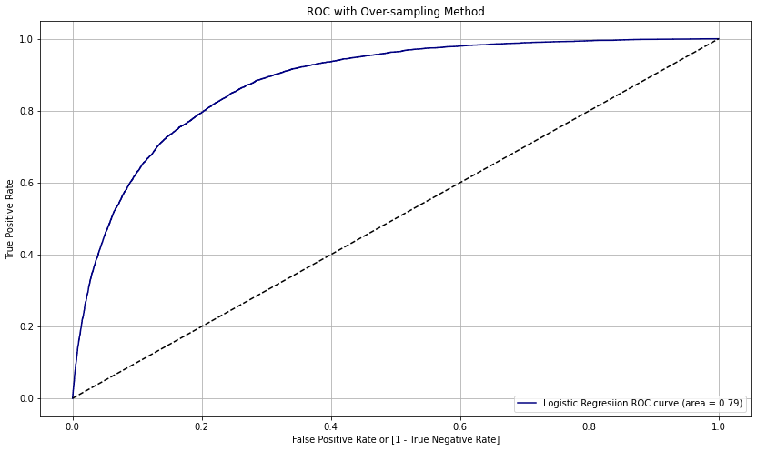

```python
fpr, tpr, thresholds = roc_curve(Y, classifier.predict_proba (X)[:,1])
auc = roc_auc_score(Y, y_pred)
plt.plot(fpr, tpr, color='navy', label='Logistic Regresiion ROC curve (area = %0.2f)' %logit_roc_score)
plt.plot([0, 1], [0, 1], 'k--')
plt.xlabel('False Positive Rate or [1 - True Negative Rate]')
plt.ylabel('True Positive Rate')
plt.grid()
plt.title("ROC with Over-sampling Method")
plt.legend(loc = "lower right")
```

### From the above analysis it is clear that with Over-Sampling method from SMOTE library Logistic Regression for the following assignment gives good AUC Score which is a measure to check accuracy of model

# Conclusions about Assignment:

> First Check data having Null Values

> Check if Target Variable is Balanced or Imbalanced

> If it is Imblanced, we have to perform Undersampling or Oversmapling whichever gives best result should be considered as Final Model

> For Treating Variables Split Data into 3 Parts:

```
 1. Continuous Variables:

     - All continuous Data must be passed through some Transformation so that data is Normalized

 2. Categorical Variables with Odinal Type data:

     - All Categorical Variables with Ordinal Type should be Label Encoded

 3. Categorical Variables with Non-Ordinal Type data:

     - All Categorical Variable with Non-Ordinal Type should be One Hot Encoded
```

> All the categorical variables before modelling must be in continuous type

> To check accuracy of model, do not conclude directly from Accuracy of Classification Report, one must also check AUC Score to give promising result of Accuracy.